# Introduction to Big Data for Social Science

Foundations of Machine Learning

Christoph Kern

## Setup

```r
# install.packages("tidyverse")
# install.packages("GGally")
# install.packages("caret")
# install.packages("pROC")
```

```r
library(tidyverse)
library(GGally)
library(caret)
library(pROC)
```

## Data

For this example, we use the census income data set from the UCI ML repository. It contains “a set of reasonably clean records” from the 1994 Census database. The prediction task is to determine whether a person makes over 50K a year.

Source: https://archive.ics.uci.edu/ml/datasets/Census+Income

First, we load the data and assign variable names.

```r
census <- read.csv("census.data", header = FALSE, na.strings = " ?")
varnames <- read.delim("census.names", header = FALSE, skip = 95)
names(census) <- as.character(varnames$V1)
```

Next, we have to clean the factor levels.

```r
cln_levels <- function(x){
  levels(x) <- make.names(gsub(" ", "", levels(x)))
  x
}
census[, c(2,4,6,7,8,9,14)] <- lapply(census[, c(2,4,6,7,8,9,14)], cln_levels)
```

In addition, we drop cases with missing values and empty factor levels.

```r
census$capital_gain[census$capital_gain >= 99990] <- NA
census <- drop_na(census)
census <- droplevels(census)
```

We also exclude some variables that we won’t use in our models.

```r
census$fnlwgt <- NULL
census$education <- NULL
census$native_country <- NULL
```

Here we rename the factor levels of the outcome variable and print the frequencies of the outcome categories.

```r
levels(census$inc) <- c("under_50K", "over_50K")
summary(census$inc)
```

```
under_50K  over_50K
    22654      7360
```

## Train and test set

Next, we want to split the data into a training (80%) and a test (20%) part. We use `createDataPartition()` from `caret` for this task, which samples within the levels of the outcome variable when splitting the data (i.e. creates stratified splits).

```r
set.seed(92385)
inTrain <- createDataPartition(census$inc,
                               p = .8,
                               list = FALSE,
                               times = 1)
census_train <- census[inTrain,]
census_test <- census[-inTrain,]
```

Using the training data, we can run some graphical data exploration using the `GGally` package.

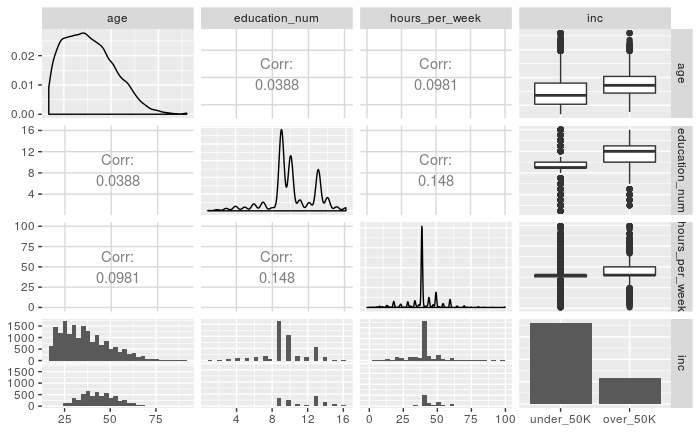

```r
ggpairs(census_train[,c(1,3,11,12)], lower = list(continuous = "cor"))
```

## Model training

The `train()` function of the `caret` package can be used to call a variety of supervised learning methods and also offers a number of evaluation approaches. For this, we first specify our evaluation method. In the following, we will use 10-fold cross-validation to evaluate the prediction performance of two logistic regression models.

```r
ctrl <- trainControl(method = "cv",
                     number = 10,
                     summaryFunction = twoClassSummary,
                     classProbs = TRUE,
                     verboseIter = TRUE)
```

Now we can call `train()`, along with the specification of the model (logistic regression) and the evaluation method (cross-validation).

```r
m1 <- train(inc ~ age + workclass + education_num + sex,
            data = census_train,
            method = "glm",
            trControl = ctrl)
```

Return the cross-validation results.

```r
m1
```

```
Generalized Linear Model

24012 samples
    4 predictors
    2 classes: 'under_50K', 'over_50K'

No pre-processing
Resampling: Cross-Validated (10 fold)
Summary of sample sizes: 21611, 21611, 21611, 21610, 21610, 21611, ...
Resampling results:

  ROC        Sens       Spec
  0.8042753  0.9349483  0.3632881
```

Next, we extend the logistic regression model by including all available features and adding quadratic terms for three predictors.

```r
m2 <- train(inc ~ . + I(age^2) + I(education_num^2) + I(hours_per_week^2),
            data = census_train,
            method = "glm",
            trControl = ctrl)
```

Again, print the cross-validation results.

```r
m2
```

```
Generalized Linear Model

24012 samples
   11 predictors
    2 classes: 'under_50K', 'over_50K'

No pre-processing
Resampling: Cross-Validated (10 fold)
Summary of sample sizes: 21610, 21612, 21611, 21610, 21611, 21611, ...
Resampling results:

  ROC        Sens       Spec
  0.9089418  0.9293755  0.615667
```

We could also return the coefficients of the trained model.

```r
summary(m2)
```

```
Call:
NULL

Deviance Residuals:
    Min       1Q   Median       3Q      Max
-3.4200  -0.5017  -0.1748  -0.0123   3.8474

Coefficients:
                                      Estimate Std. Error z value Pr(>|z|)
(Intercept)                         -1.436e+01  6.318e-01 -22.723  < 2e-16 ***
age                                  2.370e-01  1.278e-02  18.542  < 2e-16 ***
workclassLocal.gov                  -6.311e-01  1.268e-01  -4.978 6.41e-07 ***
workclassPrivate                    -3.354e-01  1.051e-01  -3.192 0.001411 **
workclassSelf.emp.inc               -1.691e-01  1.393e-01  -1.214 0.224659
workclassSelf.emp.not.inc           -7.900e-01  1.233e-01  -6.405 1.50e-10 ***
workclassState.gov                  -7.134e-01  1.418e-01  -5.032 4.86e-07 ***
workclassWithout.pay                -1.204e+01  1.410e+02  -0.085 0.931950
education_num                        1.596e-01  5.486e-02   2.909 0.003627 **
marital_statusMarried.AF.spouse      3.506e+00  6.448e-01   5.437 5.42e-08 ***
marital_statusMarried.civ.spouse     2.130e+00  3.142e-01   6.781 1.19e-11 ***
marital_statusMarried.spouse.absent -7.796e-02  2.777e-01  -0.281 0.778935
marital_statusNever.married         -2.150e-01  1.007e-01  -2.136 0.032705 *
marital_statusSeparated              8.364e-02  1.801e-01   0.464 0.642355
marital_statusWidowed                7.438e-01  1.707e-01   4.357 1.32e-05 ***
occupationArmed.Forces              -9.783e-01  1.683e+00  -0.581 0.561045
occupationCraft.repair               2.215e-02  9.208e-02   0.241 0.809902
occupationExec.managerial            8.454e-01  8.852e-02   9.551  < 2e-16 ***
occupationFarming.fishing           -8.265e-01  1.556e-01  -5.312 1.08e-07 ***
occupationHandlers.cleaners         -5.591e-01  1.622e-01  -3.446 0.000569 ***
occupationMachine.op.inspct         -3.644e-01  1.174e-01  -3.105 0.001902 **
occupationOther.service             -8.222e-01  1.362e-01  -6.039 1.55e-09 ***
occupationPriv.house.serv           -4.164e+00  2.797e+00  -1.489 0.136539
occupationProf.specialty             5.555e-01  9.377e-02   5.924 3.14e-09 ***
occupationProtective.serv            7.540e-01  1.446e-01   5.213 1.86e-07 ***
occupationSales                      3.505e-01  9.486e-02   3.695 0.000220 ***
occupationTech.support               7.262e-01  1.256e-01   5.784 7.31e-09 ***
occupationTransport.moving          -4.564e-02  1.126e-01  -0.405 0.685224
relationshipNot.in.family            3.730e-01  3.115e-01   1.198 0.231061
relationshipOther.relative          -1.974e-01  2.755e-01  -0.716 0.473723
relationshipOwn.child               -6.185e-01  3.128e-01  -1.977 0.048029 *
```

[output cut: 8 more lines]

```
capital_loss                         6.747e-04  4.344e-05  15.529  < 2e-16 ***
hours_per_week                       8.632e-02  8.054e-03  10.718  < 2e-16 ***
`I(age^2)`                          -2.310e-03  1.404e-04 -16.454  < 2e-16 ***
`I(education_num^2)`                 5.630e-03  2.621e-03   2.148 0.031734 *
`I(hours_per_week^2)`               -6.350e-04  7.757e-05  -8.186 2.70e-16 ***
---
Signif. codes:  0 ‘***’ 0.001 ‘**’ 0.01 ‘*’ 0.05 ‘.’ 0.1 ‘ ’ 1

(Dispersion parameter for binomial family taken to be 1)

    Null deviance: 26750  on 24011  degrees of freedom
Residual deviance: 15134  on 23968  degrees of freedom
AIC: 15222

Number of Fisher Scoring iterations: 12
```

## Prediction and evaluation

Finally, we can asses the performance of the selected/ best model in the previously untouched test data. For this, we create both predicted probabilities and predicted classes (based on the default threshold).

```r
p_m2 <- predict(m2, newdata = census_test, type = "prob")
c_m2 <- predict(m2, newdata = census_test)
```

The `pROC` package can be used to calculate ROC-AUCs and plot ROC curves given a vector of predicted probabilities. We first create the `roc` object.

```r
m2_roc <- roc(census_test$inc, p_m2$over_50K)
m2_roc
```

```
Call:
roc.default(response = census_test$inc, predictor = p_m2$over_50K)

Data: p_m2$over_50K in 4530 controls (census_test$inc under_50K) < 1472 cases (census_test$inc over_50K).
Area under the curve: 0.902
```

This object can be plotted with `ggroc()`, which allows to use `ggplot2` syntax.

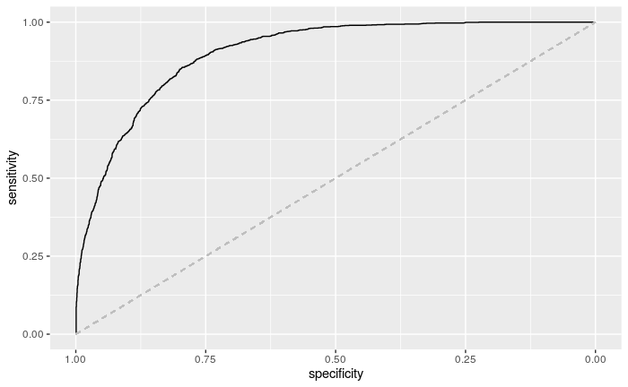

```r
ggroc(m2_roc) +
  geom_segment(aes(x = 1, xend = 0, y = 0, yend = 1), color = "grey", linetype = "dashed")
```

Lastly, we can use the predicted classes to create a confusion matrix. Note that the following results are dependent on the classification cut-off that is used (e.g., 0.5).

```r
confusionMatrix(c_m2, census_test$inc, mode = "everything", positive = "over_50K")
```

```
Confusion Matrix and Statistics

           Reference
Prediction  under_50K over_50K
  under_50K      4189      599
  over_50K        341      873

               Accuracy : 0.8434
                 95% CI : (0.8339, 0.8525)
    No Information Rate : 0.7547
    P-Value [Acc > NIR] : < 2.2e-16

                  Kappa : 0.5504

 Mcnemar's Test P-Value : < 2.2e-16

            Sensitivity : 0.5931
            Specificity : 0.9247
         Pos Pred Value : 0.7191
         Neg Pred Value : 0.8749
              Precision : 0.7191
                 Recall : 0.5931
                     F1 : 0.6500
             Prevalence : 0.2453
         Detection Rate : 0.1455
   Detection Prevalence : 0.2023
      Balanced Accuracy : 0.7589

       'Positive' Class : over_50K
```